# Reproducible Research: Assignment 1

### Loading and processing the data

```r
datos <- read.csv("./repdata_data_activity/activity.csv")
no_NA <- na.omit(datos)
rownames(no_NA) <- 1:nrow(no_NA)
head(no_NA)
```

```
##   steps       date interval
## 1     0 2012-10-02        0
## 2     0 2012-10-02        5
## 3     0 2012-10-02       10
## 4     0 2012-10-02       15
## 5     0 2012-10-02       20
## 6     0 2012-10-02       25
```

### Calculation of the mean and median total number of steps taken per day

Mean total number of steps taken per day

```r
total_number_steps <- aggregate(no_NA$steps, list(Date = no_NA$date), FUN = "sum")$x
mean(total_number_steps)
```

```
## [1] 10766
```

Median total number of steps taken per day

```r
median(total_number_steps)
```

```
## [1] 10765
```

### Histogram of the total number of steps taken each day

```
## stat_bin: binwidth defaulted to range/30. Use 'binwidth = x' to adjust this.
```

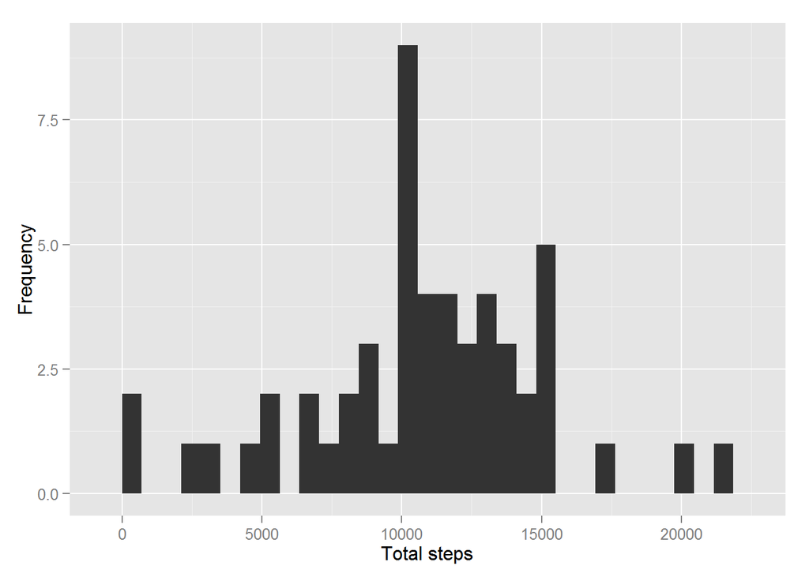

```r
library(ggplot2)
qplot(total_number_steps, xlab='Total steps', ylab='Frequency')
```

### Average daily activity pattern

Calculation of the mean steps for each five minute interval, and then put it in a data frame.

```r
steps_interval <- tapply(datos$steps, INDEX = datos$interval, FUN = mean, na.rm = TRUE)
head(steps_interval)
```

```
##       0       5      10      15      20      25
## 1.71698 0.33962 0.13208 0.15094 0.07547 2.09434
```

```r
hour<-1:length(steps_interval)/12
layout(mat = 1);
```

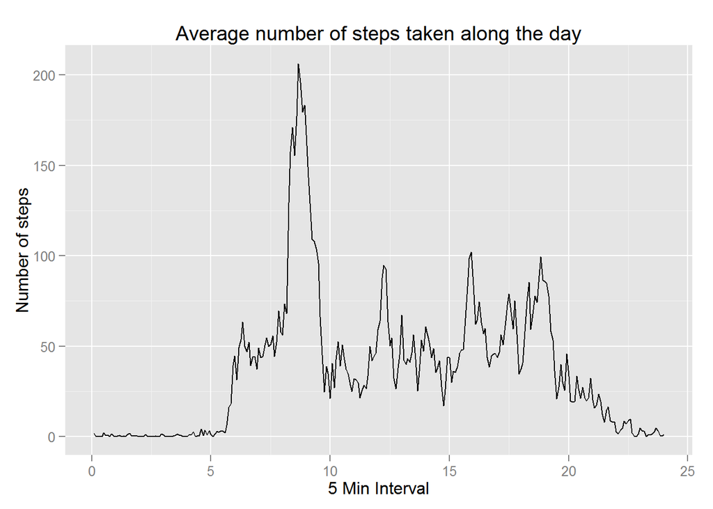

```r
qplot(y=steps_interval, x=hour, geom="line", xlab="5 Min Interval", ylab="Number of steps", main="Average number of steps taken along the day")
```

Which 5-minute interval, on average across all the days in the dataset, contains the maximum number of steps?

```r
max(steps_interval)
```

```
## [1] 206.2
```

```r
steps_interval[100:110]
```

```
##   815   820   825   830   835   840   845   850   855   900   905
## 157.5 171.2 155.4 177.3 206.2 195.9 179.6 183.4 167.0 143.5 124.0
```

The 5-minute interval that, on average across all the days in the dataset, contains the maximum number of steps is 835.

### Imputing missing values

The missing values are indicated with a NA in the original dataset. The total number of NA values s given by:

```r
sum(is.na(datos$steps));
```

```
## [1] 2304
```

The percentage of missing values is:

```r
100*sum(is.na(datos$steps)) / length(datos$steps);
```

```
## [1] 13.11
```

## Devise a strategy for filling the missing values

A very simple method is to take the mean of a 5 min interval thru all days to fill ne NA values in the corresponding interval

```r
datos$fill <- datos$steps;
filling <- rep(steps_interval,
               times = length(datos$steps) / length(steps_interval));
for (i in 1:length(datos$steps)) {
    if (is.na(datos$fill[i]))
        datos$fill[i] <- filling[i];
    }
```

We proceed to do the same calculations with the filled data. A comparison between the two summaries (with and without filling the NA values)

```r
steps_date_fill <- tapply(datos$fill, INDEX = datos$date,
                             FUN = sum);
summary(steps_date_fill);
```

```
##    Min. 1st Qu.  Median    Mean 3rd Qu.    Max.
##      41    9820   10800   10800   12800   21200
```

```r
summary(total_number_steps);
```

```
##    Min. 1st Qu.  Median    Mean 3rd Qu.    Max.
##      41    8840   10800   10800   13300   21200
```

shows that both results have the same mean and median. The histogram of the filled data shows that the original data distribution possesses fatter tails and the maximum is smaller.

```
## stat_bin: binwidth defaulted to range/30. Use 'binwidth = x' to adjust this.
```

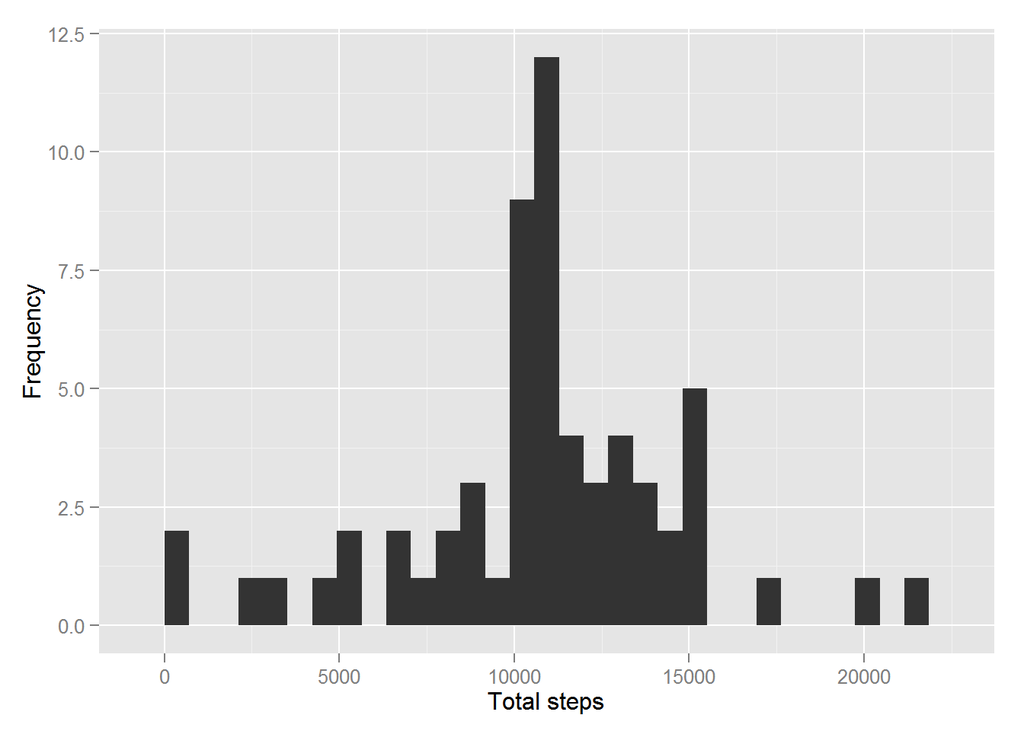

```r
qplot(steps_date_fill, xlab='Total steps', ylab='Frequency');
```